# Chapter 8: Risk and Return

FINA 3000 · Business Finance I · Class 13

Dr. Justin Mohr

October 6, 2026

## Statistical Formulas

- Expected Return

$$E(return) = \hat{r} = P_1 \ast r_1 + P_2 \ast r_2 + ... + P_N \ast r_N$$

- Standard Deviation

$$Std = \sigma = \sqrt{\sum \left( r_i - \hat{r} \right)^2 \ast P_i}$$

## Risk/Return Relationship

- Coefficient of Variation: Risk per unit of return

$$\frac{\sigma}{\hat{r}}$$

- Sharpe Ratio: Return for unit of risk

$$\frac{\hat{r} - r_f}{\sigma}$$

## Portfolios

- Owning one stock is not good. Exposed to company specific risks!
- Buy more of them, then we are able to diversify
- How does a portfolio of stocks behave?
- To find the return of a portfolio we take the weighted average
  - Weight is the proportion of the portfolio

## Portfolio Return

A fund is invested 30% in TSLA, 30% in AAPL, and 40% in GME. The expected return, $\hat{r_i}$, of TSLA is 10%, of AAPL is 15%, and of -5% for GME. What is the expected portfolio return?

$$\hat{r_p} = w_1 \ast r_1 + w_2 \ast r_2 + ... + w_N \ast r_N$$

$$\hat{r_p} = 0.3 \ast 0.1 + 0.3 \ast 0.15 + 0.4 \ast -0.05$$

$$\hat{r_p} = 5.5\%$$

## Portfolio Standard Deviation

- Returns are averaged, but what about risks?
- Generally, standard deviation of a portfolio is lower than the average of the underlying stocks
- Why?
- Negative correlations are an example
  - What is good for Taylor’s Cupcakes is bad for Justin’s Cupcakes
- Imagine two stocks that are perfectly negatively correlated
  - Opposite movements

## Negative Correlation

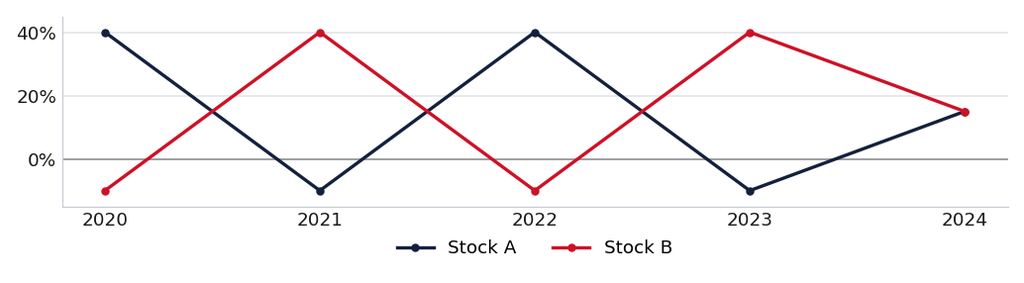

| Year | Stock A | Stock B | Porfolio |
| --- | --- | --- | --- |
| 2020 | 40% | -10% | 15% |
| 2021 | -10% | 40% | 15% |
| 2022 | 40% | -10% | 15% |
| 2023 | -10% | 40% | 15% |
| 2024 | 15% | 15% | 15% |
| Avg Ret | 15% | 15% | 15% |
| St. Dev | 0.25 | 0.25 | 0.00 |

## Portfolio Smoothing

- Stocks that are exactly opposite moving have negative correlation
- Stocks that move perfectly together are positively correlated
- An other example of the benefit of portfolios is that they smooth returns
- How to think about this?
  - Student grades

## Portfolio Smoothing

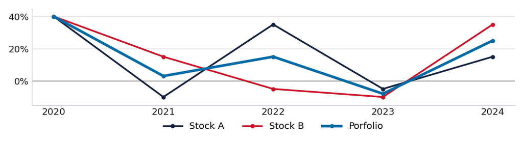

Two stocks that are not opposites, and the portfolio still swings less

| Year | Stock A | Stock B | Porfolio |
| --- | --- | --- | --- |
| 2020 | 40% | 40% | 40% |
| 2021 | -10% | 15% | 3% |
| 2022 | 35% | -5% | 15% |
| 2023 | -5% | -10% | -8% |
| 2024 | 15% | 35% | 25% |
| Avg Ret | 15% | 15% | 15% |
| St. Dev | 0.226 | 0.226 | 0.19 |

## Market Vs Diversifiable Risk

- Portfolios risk can be divided into two parts
- Diversifiable risk
  - Company specific risks
  - Risks that can be removed with diversification
- Market Risk
  - Risk that remains after diversification
  - Risk that is shared among all stocks

## What risk should we price

- I only price the risk that is shared with the market!
- If a risk that is diversifiable is being rewarded with return, then diversified investors will come and bid the price of the stock up
- Relevant risk
  - The risk that remains once a stock is in a diversified portfolio
  - How does it add to my risk of my portfolio?
- Well, what amount does it move with the market return?

## CAPM

- Capital Asset Pricing Model
- Proposition
  - Any stocks required return is equal to the risk free rate plus a risk premium for the risks remaining after diversification (market risk)
- Beta
  - This is the main result from the model
  - How much does my stock move this the market return

## Beta

[figure not shown]

- $\beta$ or b as your book says is the relationship between the Market return and the return of a stock.
- Rise over Run
- Beta of 1 is average
- Beta of 2 is high
- Beta of -1?

Five years of returns on the market and on stocks H, A and L

| Year | r<sub>M</sub> | r<sub>H</sub> | r<sub>A</sub> | r<sub>L</sub> |
| --- | --- | --- | --- | --- |
| 1 | 10.0% | 10.0% | 10.0% | 10.0% |
| 2 | 20.0% | 30.0% | 20.0% | 15.0% |
| 3 | -10.0% | -30.0% | -10.0% | 0.0% |
| 4 | 0.0% | -10.0% | 0.0% | 5.0% |
| 5 | 5.0% | 0.0% | 5.0% | 7.5% |

## Portfolio Beta

Assume you have 1M dollars invested in a 1.2 beta portfolio. You will purchase 0.5M of a 2 beta stock.

What will happen to the portfolio beta?

- It will go up! A riskier stock as been added so the risk of the portfolio goes up

What will the new portfolio beta be?

$$b_p = w_1 b_1 + w_2 b_2 + ... + w_N b_N$$

$$b_p = \frac{1}{1.5} \ast 1.2 + \frac{0.5}{1.5} \ast 2 = 1.47$$

## Market Risk Premium

- The price of risk or the risk premium
  - This is the additional rate of return that is required to hold a risky asset over a less risky one
- Construct a market portfolio
  - The average return of that portfolio historically is 8%
- We use the risk-free rate as our less risky benchmark

$$r_{rf} = r^* + IP$$

- In practice we use a treasury bill as the risk free rate
  - I will ask questions using either rate
- Then our market risk premium is

$$RP_m = r_m - r_{rf}$$

- Note on notation: $\hat{r_i}$ is expected return; $r_i$ is required return

## Remember bonds

- I need to be compensated for risk!
- Here the risk I need to be compensated for is the risk free rate and the risk premium required for that stock
- Think of the risk that needs to be compensated for holding the market
- The market has a beta of 1 so it just needs to be compensated for 1 times the risk premium of the market

$$r_m = r_{rf} + RP_m$$

## A 2 Beta stock

- What if you have a stock with a beta of two?
- You have twice the risk! So, you need double the compensation

$$r_i = r_{rf} + RP_m \ast 2$$

## SML

- We can express this more generally
- The compensation I require is the risk free rate plus compensation for the market risk I am exposed to
- This line is called the Securities Market Line

$$r_i = r_{rf} + RP_m \ast b_i$$

## SML

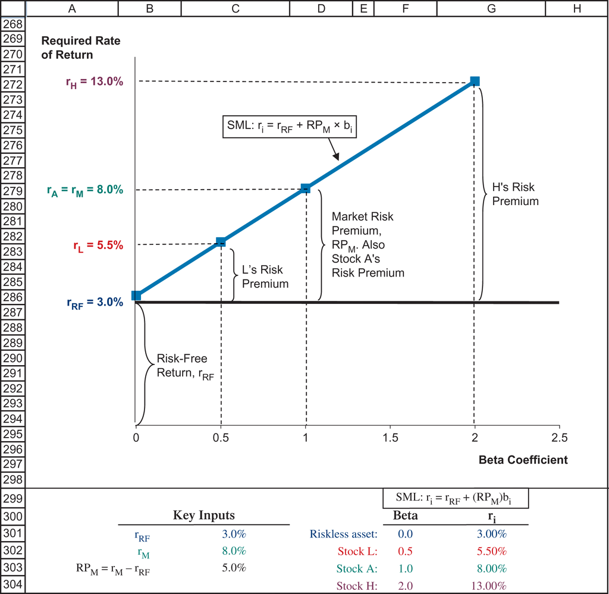

- $r_H$ has a beta of 2
- $r_A$ has a beta of 1
- $r_L$ has a beta of 0.5
- What would a zero beta stock earn?

$$\begin{array}{rl}
r_i &= r_{rf} + RP_m \ast b_i \\
RP_m &= 5\% \\
r_{rf} &= 3\%
\end{array}$$

## Example

Your stock has a beta of 1.2. The market risk premium is 5% and the risk free rate is 3%. What is the required rate of return on your stock?

$$r_i = r_{rf} + RP_m b_i$$

$$r_i = 3\% + 5\% \ast 1.2 = 9$$

What is the return on the market, $r_m$?

$$r_m = r_{rf} + RP_m$$

$$r_m = 3\% + 5\% = 8\%$$

## How does the SML change

- Inflation
  - If the inflation expectations increase then investors need to be compensated for that. This will raise $r_{rf}$ AND therefore all required rates of returns!
  - Same as bonds

## Inflation

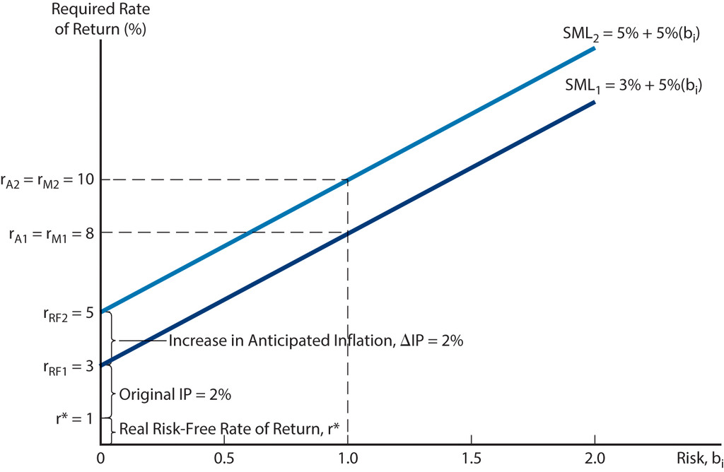

## How does the SML change

- Inflation
  - If the inflation expectations increase, then investors need to be compensated for that. This will raise $r_{rf}$ AND therefore all required rates of returns!
  - Same as bonds
- Risk aversion
  - If investors become more risk averse, then they want more compensation for risk! This means that the risk premium goes up and the slope of the SML will change
  - Slope=RP of the market

## Slope

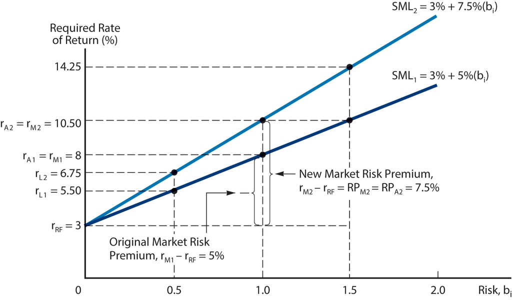

## Risk and Return

Two stocks, with the risk free rate at 6% and a market premium of 5%

|  | Stock X | Stock Y |
| --- | --- | --- |
| Beta | 0.9 | 1.2 |
| Expected Return | 10% | 12.5% |
| SD | 35% | 25% |

- The RF is 6% and market premium is 5%
- What is the CV?
- Each required rate of return?
- You invest $7.5K in X and $2.5K in Y what the required return of the portfolio?
- If the market risk premium increased to 6% which stock has the largest increase in required return?

$$CV_x = \frac{\sigma_x}{\hat{r_x}} = \frac{35\%}{10\%} = 3.5$$

$$CV_y = \frac{\sigma_y}{\hat{r_y}} = \frac{25\%}{12.5\%} = 2$$

$$r_x = 6\% + 0.9 \ast 5\% = 10.5\%$$

$$r_y = 6\% + 1.2 \ast 5\% = 12\%$$

$$\beta_p = 0.9 \ast \frac{7500}{10000} + 1.2 \ast \frac{2500}{10000} = 0.975$$

$$r_p = 6\% + 0.975 \ast 5\% = 10.875\%$$

$$r_x = 6\% + 0.9 \ast 6\% = 11.4\%$$

$$r_y = 6\% + 1.2 \ast 6\% = 13.2\%$$

## CAPM and required return

You manage a $5M portfolio and a $\beta$ of 1.15 and a required rate of return of 11.475%. The current risk-free rate is 4%. Assume you receive another $500k. If you invest the money in a stock with a $\beta$ of 0.85, what will be the required return on your portfolio?

$$R_i = R_f + RP_m \ast \beta_p$$

- What is $RP_m$?

$$11.475 = 4 + RP_m \ast 1.15 \rightarrow RP_m = \frac{11.475 - 4}{1.15} = 6.5$$

- Portfolio Beta

$$\frac{5M \ast 1.15 + 0.5M \ast 0.85}{5.5} = \frac{6.175}{5.5} = 1.12$$

- Required Return

$$R_i = 4 + 6.5 \ast \frac{6.175}{5.5} = 11.30$$

## Over and undervalued

- The CAPM tells you the return you should REQUIRE for the risk you are taking
- Work out the return you EXPECT from the price
- Compare the two

What does it mean if the two are not equal?

Expected above required: the price is too low. Undervalued, and you buy it.

Expected below required: the price is too high. Overvalued.

## Should you buy LMARK?

Shares of LMARK currently trade at $18.00. You expect the price to be $19.58 in one year (no dividends). The S&P 500 expected return is 11.00%, the T-bill rate is 3.00%, and LMARK has a beta of 1.1.

Should you buy this stock?

Expected: $(19.58 - 18.00)/18.00 = 8.78\%$ Required: $3\% + 1.1(11\% - 3\%) = 11.80\%$

**8.78% is below 11.80%, so LMARK is overvalued. Do not buy it.**

[figure not shown]

What would it have to trade at today for it to be correctly valued?

Hint(discount the expected price with the correct rate)

$19.58 / 1.118 = **$17.51**, so it is about 49 cents too expensive.

## Practice: Required Rate of Return

- The risk free rate is 4%, that market return is 10%, and your stock’s $\beta$ is 1.4.
- What is the required rate of return on your stock?

$$r_i = r_{rf} + \beta \ast \left( r_m - r_{rf} \right)$$

$$r_i = 4 + \left( 10 - 4 \right) \ast 1.4 = 12.4\%$$

- The risk free rate increases to 5% and the slope of the SML is the same. What is the return on the market? On your stock?

If the slope is the same, then $\left( r_m - r_{rf} \right)_1 = \left( r_m - r_{rf} \right)_2$

so $r_m = r_{rf} + RP = 5 + 6 = 11$

$$r_i = 5 + \left( 11 - 5 \right) \ast 1.4 = 13.4\%$$

- The risk free is 4%, but the market return increases to 12% what is $r_i$?

$$r_i = 4 + \left( 12 - 4 \right) \ast 1.4 = 15.2\%$$

## Practice

Two stocks over five states of the world

| Probability | Stock A | Stock B |
| --- | --- | --- |
| 0.1 | (10%) | (35%) |
| 0.2 | 2% | 0% |
| 0.4 | 12% | 20% |
| 0.2 | 20% | 25% |
| 0.1 | 38% | 45% |

- The risk free rate is 2.5%
- Calculate the expected rate of return, standard deviation for stock A
- Also the coefficient of variance, and Sharpe ratio for each stock
- Standard deviation of Stock B is 20.35%

$$\sigma = \sqrt{\sum \left( r_i - \hat{r} \right)^2 \ast P_i}$$

## Practice Solution

- Expected Return

Stock 1: $0.1 \ast -10 + 0.2 \ast 2 + 0.4 \ast 12 + 0.2 \ast 20 + 0.1 \ast 38 = 12\%$

Stock 2: $0.1 \ast -35 + 0.2 \ast 0 + 0.4 \ast 20 + 0.2 \ast 25 + 0.1 \ast 45 = 14\%$

- Standard deviation of Stock A

$$\sigma = \sqrt{0.1 \ast \left( -10 - 12 \right)^2 + 0.2 \ast \left( 2 - 12 \right)^2 + 0.4 \ast \left( 12 - 12 \right)^2 + 0.2 \ast \left( 20 - 12 \right)^2 + 0.1 \ast \left( 38 - 12 \right)^2} = 12.20$$

- Coefficient of variation

Stock A: 12.2/12=1.01 Stock B: 20.35/14=1.45

Which is riskier? How much risk do I accept for each 1% of return?

- Sharpe Ratio

Which ratio is better?

## Upcoming Dates

Upcoming class dates and deadlines

| Date | Topic | Due / Notes |
| --- | --- | --- |
| Thu Oct 8 | Chapter 9: Stocks (part 1) | - |
| Sun Oct 11 | MindTap Ch 8 | HW DUE |
| Mon Oct 12 | Deadline for course withdrawals (no refund; refund period ended September 4th) | DEADLINE |
| Tue Oct 13 | Review for Test 2 | Review |

**Office:** 325 Holman Hall · **Office hours:** T TH 10:50A-12:20P · jjmohr1@olemiss.edu